# Predict Housing Value of Seattle, WA

Ziyi Guo, Junyi Yang

To develop a comprehensive predictive model for housing prices in Seattle, we will consider a range of variables that encompass the internal condition of houses, their structural characteristics, spatial location, and available amenities.

Specifically, our model will take into account the internal condition of houses, including aspects such as interior quality, age of appliances, and recent renovations. Structural characteristics such as property size, number of bedrooms and bathrooms, architectural style, and construction materials will also be included. Additionally, the model will consider the spatial location of properties, including their proximity to key urban centers, waterfront areas, and green spaces. Finally, the availability of local amenities such as schools, hospitals, shop ping centers, public transportation, and recreational facilities will be factored into the model.

By integrating these diverse variables, our predictive model aims to accurately capture the factors that influence housing prices in Seattle, providing valuable insights for stakeholders in the real estate market.

## 1. Data Wrangling

### 1.1 Access the Data

1. Load the initial housing data and trim it to fit within the boundaries of Seattle city.

```r
# initial housing data
housingData <-
  read.csv(file.path("./dataWithoutcrime/kc_house_data.csv"))

Seattle.sf <-
  housingData %>%
  st_as_sf(coords = c("long", "lat"), crs = 4326, agr = "constant") %>%
  st_transform(crs = 2926) %>%
  mutate(price_per_sqft = price / sqft_lot)

# Seattle geo_Tracts
tracts <-
  st_read("./dataWithoutcrime/2010_Census_Tract_Seattle.geojson") %>%
  st_transform(crs = 2926)

#Cut the housing data to fit into the Seattle boundary
Seattle.sf_tracts <- st_intersection(Seattle.sf, tracts)

Seattle.sf_tracts2 <- Seattle.sf_tracts %>%
  select(id, date, price ,bedrooms, bathrooms, sqft_living, sqft_lot, floors, waterfront, view, condition, grade, yr_built, yr_renovated, zipcode, price_per_sqft, geometry)
```

2. Identify variables that are likely to influence housing values, such as safety metrics, tree canopy coverage, and proximity to transit options. Obtain the relevant data from the Seattle Open Data Portal. https://data.seattle.gov/ https://www.seattle.gov/tech/reports-and-data/open-data https://data-seattlecitygis.opendata.arcgis.com/

```r
# Add-in Data

# Seattle neighborhood
neighborhood <-
  st_read("C:/Users/25077/Desktop/MUSA 508_PPA/5_/github/local/seattle-housing/dataWithoutcrime/Neighborhood_Map.geojson") %>%
  st_transform(crs = 2926)

## social
crime <- read.csv(file.path("C:/Users/25077/Desktop/PPA_Midterm/SPD_Crime_Data.csv"))

Crime.sf <-
  crime %>%
  st_as_sf(coords = c("Longitude", "Latitude"), crs = 4326, agr = "constant") %>%
  st_transform(crs = 2926)


## Amenities
School <-
  st_read("./dataWithoutcrime/Private_School.geojson") %>%
  st_transform(crs = 2926)

Parks <-
  st_read("./dataWithoutcrime/seattle-parks-osm.geojson") %>%
  st_transform(crs = 2926)

Hospital <-
  st_read("./dataWithoutcrime/Hospital.geojson") %>%
  st_transform(crs = 2926)

## Streetcar
streetcar <-
  st_read("C:/Users/25077/Desktop/MUSA 508_PPA/5_/github/local/seattle-housing/dataWithoutcrime/streetcar_3857.geojson") %>%
  st_transform(crs = 2926)

## Traffic flow
traffic <-
  st_read("C:/Users/25077/Desktop/MUSA 508_PPA/5_/github/local/seattle-housing/dataWithoutcrime/traffic_3857.geojson") %>%
  st_transform(crs = 2926)

## canopy
canopy <-
  st_read("C:/Users/25077/Desktop/MUSA 508_PPA/5_/github/local/seattle-housing/dataWithoutcrime/tree_3857.geojson") %>%
  st_transform(crs = 2926)

## Crosswalk
crosswalk <-
  st_read("C:/Users/25077/Desktop/MUSA 508_PPA/5_/github/local/seattle-housing/dataWithoutcrime/Marked_Crosswalks.geojson") %>%
  st_transform(crs = 2926)
```

3. Convert the spatial character data into variables that may impact housing values, such as the presence of nearby amenities around a particular house and the distance from these amenities to the property. Create buffers around housing locations based on accessible distances. Within these buffers, tally the count of amenities to evaluate the density of local services. Additionally, calculate the distance to the nearest k amenities, providing a granular view of a property’s convenience and potential appeal to buyers.

```r
# SAFETY

Seattle.sf_tracts2$crime.Buffer <- Seattle.sf_tracts2 %>%
    st_buffer(660) %>%
    aggregate(dplyr::select(Crime.sf) %>%
    mutate(counter = 1), ., sum)

Seattle.sf_tracts2 <-
  Seattle.sf_tracts2 %>%
    mutate(
      crime_nn1 = nn_function(st_coordinates(Seattle.sf_tracts2),
                              st_coordinates(Crime.sf), k = 1),

      crime_nn2 = nn_function(st_coordinates(Seattle.sf_tracts2),
                              st_coordinates(Crime.sf), k = 2),

      crime_nn3 = nn_function(st_coordinates(Seattle.sf_tracts2),
                              st_coordinates(Crime.sf), k = 3),

      crime_nn4 = nn_function(st_coordinates(Seattle.sf_tracts2),
                              st_coordinates(Crime.sf), k = 4),

      crime_nn5 = nn_function(st_coordinates(Seattle.sf_tracts2),
                              st_coordinates(Crime.sf), k = 5))

# SCHOOLS

#count the school number within the buffer
Seattle.sf_tracts2$school.Buffer <- Seattle.sf_tracts2 %>%
    st_buffer(5280) %>%
    aggregate(dplyr::select(School ) %>%
    mutate(counter = 1), ., sum)

Seattle.sf_tracts2 <-
  Seattle.sf_tracts2 %>%
    mutate(
      school_nn1 = nn_function(st_coordinates(Seattle.sf_tracts2),
                              st_coordinates(School), k = 1),
      )


#HOSPITALS

Seattle.sf_tracts2$hosp.Buffer <- Seattle.sf_tracts2 %>%
    st_buffer(5280) %>%
    aggregate(dplyr::select(Hospital) %>%
    mutate(counter = 1), ., sum)

Seattle.sf_tracts2 <-
  Seattle.sf_tracts2 %>%
    mutate(
      hosp_nn1 = nn_function(st_coordinates(Seattle.sf_tracts2),
                              st_coordinates(Hospital), k = 1))


# PARKS

Seattle.sf_tracts2$parks.Buffer <- Seattle.sf_tracts2 %>%
    st_buffer(1320) %>%
    aggregate(dplyr::select(Parks) %>%
    mutate(counter = 1), ., sum)


# CROSSWALK

Seattle.sf_tracts2$crosswalk.Buffer <- Seattle.sf_tracts2 %>%
    st_buffer(1320) %>%
    aggregate(dplyr::select(crosswalk) %>%
    mutate(counter = 1), ., sum)


# STREETCAR STATION

# Streetcar buffer
streetcar.Buffer <- st_union(st_buffer(streetcar, dist=1000))

# Assign to overall dataframe
Seattle.sf_tracts2$streetcar.station <- st_within(Seattle.sf_tracts2, streetcar.Buffer) %>% lengths > 0


# CANOPY

# join canopy to housing points
Seattle.sf_tracts3 <- st_join(Seattle.sf_tracts2, canopy, left = TRUE)

Seattle.sf_tracts3 <- Seattle.sf_tracts3 %>%
  st_drop_geometry() %>%
  select(id, Can_P)

# put the column into the overall dataframe
Seattle.sf_tracts2$canopy <- Seattle.sf_tracts3["Can_P"]


# DISTANCE TO MAJOR ROADS

# Convert Seattle.sf_tracts2 to a point pattern, specifying mark column(s)
Seattle_points <- as.ppp(Seattle.sf_tracts2)

# Convert traffic to a line segment pattern
traffic_lines <- as.psp(traffic)

# Find nearest line segment to each point
nearest_segments <- nncross(Seattle_points, traffic_lines)

# put the column into the overall dataframe
Seattle.sf_tracts2$distance <- nearest_segments['dist']



# DEMOGRAPHICS

Demo <- get_acs(geography = "tract",
          survey = "acs5",
          variables = c("B01001_001E", "B01001A_001E", "B06011_001E"),
          year = 2018,
          state = "53",
          county = "033",
          geometry = T,
          output = "wide") %>%
  st_transform(crs = 2926) %>%
  rename(TotalPop = B01001_001E,
         NumberWhites = B01001A_001E,
         MedIncome = B06011_001E) %>%
  mutate(pctWhite = NumberWhites / TotalPop)%>%
  select(-NAME, -GEOID)

Demo <- st_transform(Demo, st_crs(Seattle.sf_tracts2))

# FINALIZE

#Join the demographics data
#Clean the data

Seattle.sf_tracts2 <- st_join(Seattle.sf_tracts2, Demo, left = TRUE)
Seattle.sf_tracts2 <- Seattle.sf_tracts2 %>%
  select(-contains("B01"), -contains("B06"))%>%
  mutate(Age = 2024 - yr_built, parksCount = parks.Buffer$counter, crimeCount=crime.Buffer$counter, schoolCount=school.Buffer$counter, hospitalCount=hosp.Buffer$counter, crosswalkCount=crosswalk.Buffer$counter, canopyPercent=canopy$Can_P, TrafficDis=distance$dist)
```

### 1.2 Summarize and Preview the Variables

Categorize the collected and initial data, and provide a summary of the statistics.

```r
## delete the geometry column
table_Seattle <- Seattle.sf_tracts2 %>% st_drop_geometry()

#category of the data

#internal_character
internal_character_df <- table_Seattle[, c("bedrooms", "bathrooms", "sqft_living","sqft_lot", "floors", "condition", "grade")]
internal_character <- round(do.call(cbind, lapply(internal_character_df, summary)), digits = 2)

#Structure_character
Structure_character_df <- table_Seattle[, c("condition", "grade", "Age", "yr_renovated")]
Structure_character <- round(do.call(cbind, lapply(Structure_character_df, summary)), digits = 2)

#amenities
amenities_df <- table_Seattle[, c("parksCount", "schoolCount", "hospitalCount", "crosswalkCount", "canopyPercent", "hosp_nn1", "school_nn1")]
amenities <- round(do.call(cbind, lapply(amenities_df, summary))[1:6,], digits = 2)

#distance column for some reason need to be calculated separatly
distance_extract_df <- table_Seattle[, c("distance")]
distance_extract <- round(do.call(cbind, lapply(distance_extract_df, summary)), digits = 2)

amenities_all <- cbind(amenities, distance_extract)


#spatial_character
spatial_character_df <- table_Seattle[, c( "waterfront", "view")]
spatial_character <- round(do.call(cbind, lapply(spatial_character_df, summary)), digits = 2)

#safety
safety_df <- table_Seattle[, c( "crime_nn1","crime_nn2","crime_nn3","crime_nn4","crime_nn5", "crimeCount")]
safety <- round(do.call(cbind, lapply(safety_df, summary)), digits = 2)

#Demographics
Demographics_df <- table_Seattle[, c( "TotalPop", "MedIncome", "pctWhite")]
Demographics <- round(do.call(cbind, lapply(Demographics_df, summary))[1:6,], digits = 2)


# Combine the summaries into one data frame
summary_data <- cbind(internal_character, Structure_character, amenities_all,
                      spatial_character, safety, Demographics)

long_summary_data <- as.data.frame(t(summary_data)) %>%
  rename('Minimum' = 'Min.',
         '1st Quantile' = '1st Qu.',
         '3rd Quantile' = '3rd Qu.',
         'Maximun' = 'Max.')

#generate table
kb <- kbl(long_summary_data, caption = "Statistics Summary") %>%
  kable_styling(bootstrap_options = c("striped", "hover", "condensed")) %>%
  pack_rows("Internal Character", 1, 7) %>%
  pack_rows("Structure Character", 8, 11) %>%
  pack_rows("Amenities", 12, 19) %>%
  pack_rows("Spatial character", 20, 21) %>%
  pack_rows("Safety", 22, 27) %>%
  pack_rows("Demographics", 28, 30)

kb
```

Statistics Summary

|  | Minimum | 1st Quantile | Median | Mean | 3rd Quantile | Maximun |
| --- | --- | --- | --- | --- | --- | --- |
| **Internal Character** |  |  |  |  |  |  |
| bedrooms | 0.00 | 2.00 | 3.00 | 3.14 | 4.00 | 33.00 |
| bathrooms | 0.00 | 1.00 | 1.75 | 1.94 | 2.50 | 8.00 |
| sqft_living | 370.00 | 1240.00 | 1626.00 | 1801.79 | 2200.00 | 12050.00 |
| sqft_lot | 520.00 | 3240.00 | 4950.00 | 5124.03 | 6330.00 | 91681.00 |
| floors | 1.00 | 1.00 | 1.50 | 1.54 | 2.00 | 3.50 |
| condition | 1.00 | 3.00 | 3.00 | 3.45 | 4.00 | 5.00 |
| grade | 4.00 | 7.00 | 7.00 | 7.43 | 8.00 | 13.00 |
| **Structure Character** |  |  |  |  |  |  |
| condition.1 | 1.00 | 3.00 | 3.00 | 3.45 | 4.00 | 5.00 |
| grade.1 | 4.00 | 7.00 | 7.00 | 7.43 | 8.00 | 13.00 |
| Age | 9.00 | 37.00 | 77.00 | 70.68 | 99.00 | 124.00 |
| yr_renovated | 0.00 | 0.00 | 0.00 | 132.46 | 0.00 | 2015.00 |
| **Amenities** |  |  |  |  |  |  |
| parksCount | 1.00 | 1.00 | 2.00 | 2.31 | 3.00 | 16.00 |
| schoolCount | 1.00 | 2.00 | 3.00 | 3.82 | 5.00 | 14.00 |
| hospitalCount | 1.00 | 1.00 | 1.00 | 1.32 | 1.00 | 5.00 |
| crosswalkCount | 1.00 | 5.00 | 10.00 | 12.12 | 16.00 | 83.00 |
| canopyPercent | 4.23 | 23.12 | 27.72 | 29.08 | 34.04 | 60.40 |
| hosp_nn1 | 292.19 | 5682.65 | 8541.55 | 9942.49 | 12788.58 | 25810.66 |
| school_nn1 | 52.05 | 1525.20 | 2449.55 | 2954.18 | 3800.21 | 17319.46 |
| dist | 0.04 | 157.94 | 319.35 | 402.60 | 551.22 | 2840.94 |
| **Spatial character** |  |  |  |  |  |  |
| waterfront | 0.00 | 0.00 | 0.00 | 0.00 | 0.00 | 1.00 |
| view | 0.00 | 0.00 | 0.00 | 0.29 | 0.00 | 4.00 |
| **Safety** |  |  |  |  |  |  |
| crime_nn1 | 3.68 | 75.27 | 106.82 | 113.58 | 145.41 | 603.42 |
| crime_nn2 | 3.68 | 77.55 | 109.34 | 115.70 | 148.09 | 603.42 |
| crime_nn3 | 3.68 | 78.99 | 111.54 | 117.61 | 150.03 | 603.42 |
| crime_nn4 | 3.96 | 80.13 | 112.90 | 119.33 | 152.13 | 609.48 |
| crime_nn5 | 3.96 | 81.80 | 114.54 | 121.04 | 153.74 | 613.11 |
| crimeCount | 11.00 | 227.00 | 371.00 | 512.19 | 632.00 | 6534.00 |
| **Demographics** |  |  |  |  |  |  |
| TotalPop | 1115.00 | 4702.00 | 5674.00 | 5830.97 | 7058.00 | 9508.00 |
| MedIncome | 9190.00 | 40325.00 | 51702.00 | 50163.25 | 58271.00 | 77568.00 |
| pctWhite | 0.09 | 0.62 | 0.79 | 0.71 | 0.84 | 0.93 |

Based on the initial housing datasets, we have incorporated additional spatially-oriented data related to amenities and safety. The overall data can now be categorized into several key areas:

Internal Characteristics: This includes features such as the number of bedrooms and the grade of the property. Structural Characteristics: These are aspects related to the condition, age, and structural features of the property. Amenities: This category covers the proximity and accessibility of essential services such as hospitals and schools. Traffic Accessibility: This includes factors such as the presence of crosswalks and the distance to major roads. Spatial Characteristics: These are features related to the property’s location, such as waterfront views. Safety and Demographic Issues: This category encompasses data related to the safety of the area and demographic characteristics of the surrounding community.

These enhancements to the dataset provide a more comprehensive understanding of the housing market, taking into account a wider range of factors that can influence property values and desirability.

### 1.3 Variable Maps

1. Housing Price Map

[figure not shown]

```r
## Current housing price map
Seattle.sf_tracts2$quintiles <- ntile(Seattle.sf_tracts2$price, 5)

# Convert quintiles to a factor if not already done
Seattle.sf_tracts2$quintiles <- as.factor(Seattle.sf_tracts2$quintiles)
Palette5 <- brewer.pal(5, "YlGnBu")

# Generate the plot
ggplot() +
  geom_sf(data = tracts, fill = "lightgrey", col = "white") +
  geom_sf(data = Seattle.sf_tracts2, aes(colour = quintiles), show.legend = "point", size = .25) +
  scale_colour_manual(values = Palette5,
                      labels = c("Low", "Relatively Low", "Medium", "Relatively High", "High"),
                      name = "Price Per Square Foot Quintiles") +
  labs(title = "Price Per Square Foot, Seattle") +
  theme_void()
```

2. Streetcar Station and Service Area Map

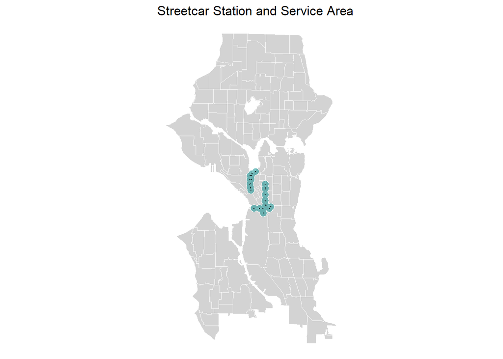

```r
## Street Car Station and Buffer
ggplot() +
  geom_sf(data = tracts, fill = "lightgrey", col = "white") +
  geom_sf(data = streetcar.Buffer, fill = "cyan4", col = "white", alpha = 0.5) +
  geom_sf(data = streetcar, col = "black", show.legend = "point", size = .25) +
  labs(title = "Streetcar Station and Service Area") +
  theme_void()
```

3. Hospital Distribution Map

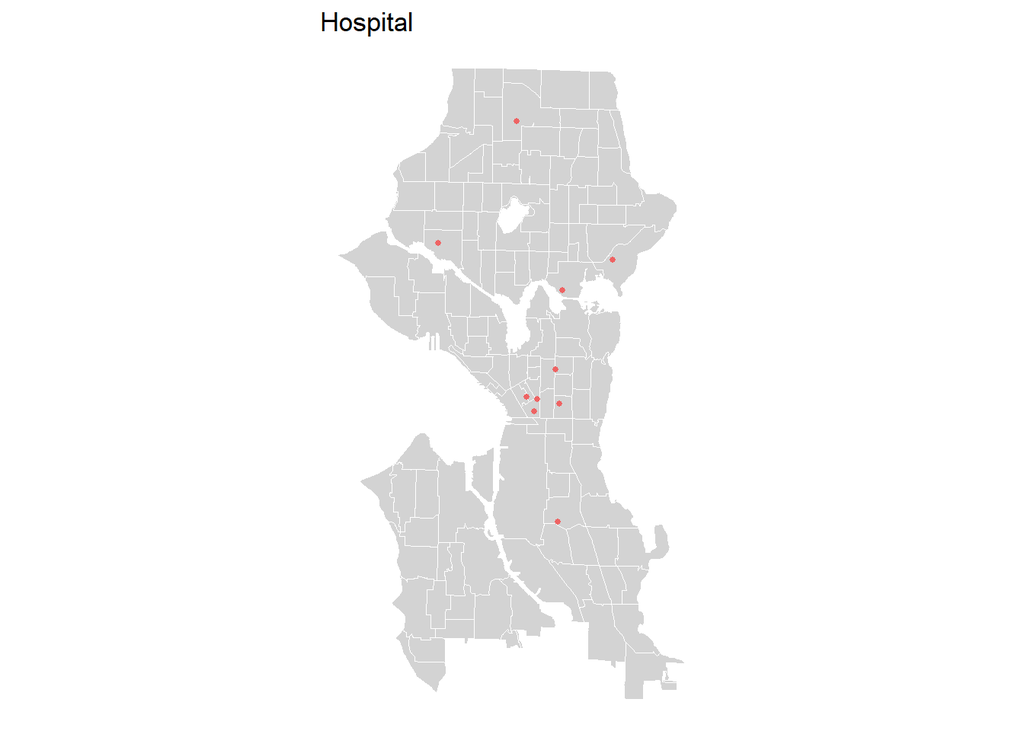

```r
## Hospital
Hospital_clipped <- st_intersection(Hospital, tracts)
ggplot() +
  geom_sf(data = tracts, fill = "lightgrey", col = "white") +
  geom_sf(data = Hospital_clipped, size =1, color = "indianred2") +
  labs(title = "Hospital") +
  theme_void()
```

4. Median Income Map

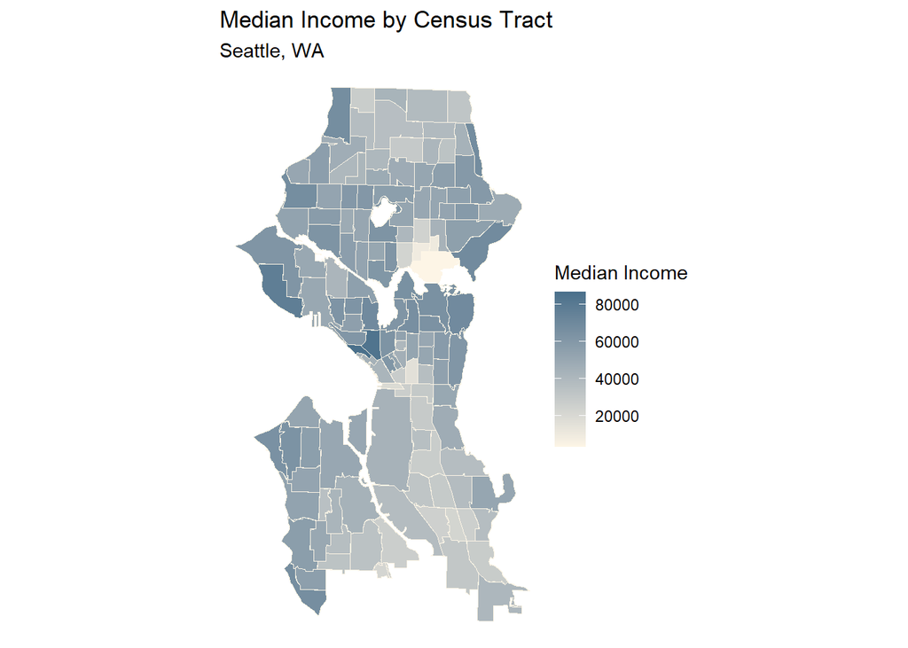

```r
## MedIncome
Demo_clipped <- st_intersection(Demo, tracts)
ggplot(data = Demo_clipped) +
  geom_sf(aes(fill = MedIncome),color = "oldlace", size=0.1) +  # Use MedIncome for the fill color
  scale_fill_gradient(low = "oldlace", high = "skyblue4",
                      name = "Median Income") +  # Adjust color gradient as needed
  labs(title = "Median Income by Census Tract",
       subtitle = "Seattle, WA") +
    theme_void()
```

## 2. Analysis Variables

### 2.1 Analyzing associations

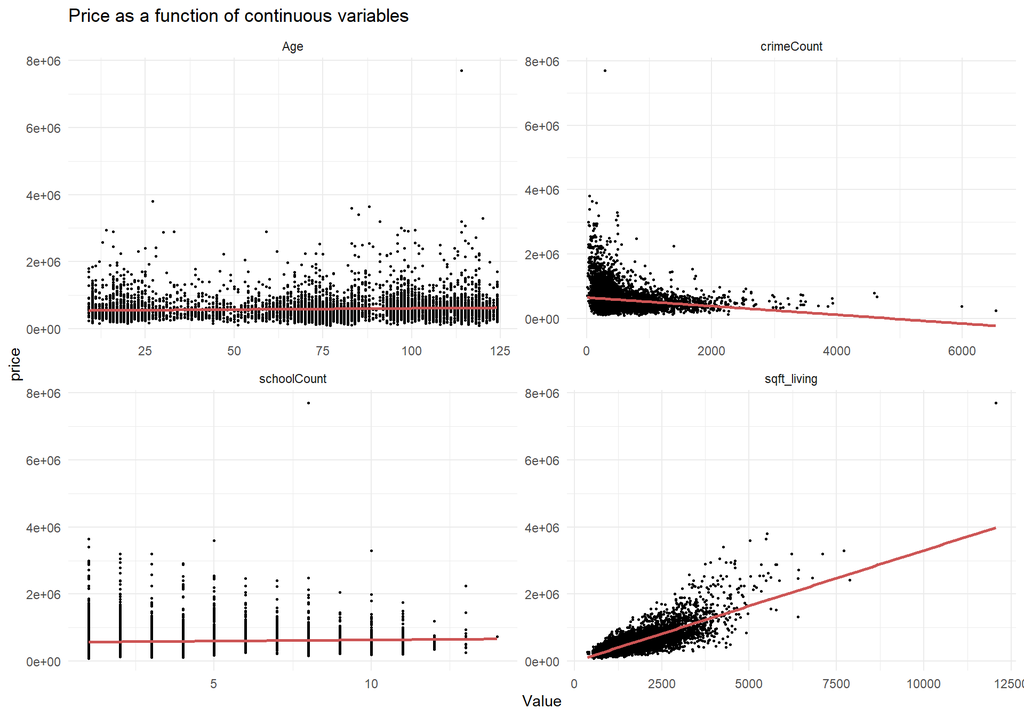

```r
# Remove geometry column (if present), calculate Age, and select relevant variables
Seattle <- st_drop_geometry(Seattle.sf_tracts2) %>%
  select(price, sqft_living, Age, crimeCount, schoolCount) %>%
  filter(Age < 500)


Seattle_long <- gather(Seattle, Variable, Value, -price)

# Create scatterplot with linear regression lines for each variable
ggplot(Seattle_long, aes(Value, price)) +
  geom_point(size = .5) +
  geom_smooth(method = "lm", se = FALSE, colour = "indianred3") +
  facet_wrap(~Variable, ncol = 2, scales = "free") +
  labs(title = "Price as a function of continuous variables") +
  theme_minimal()
```

The age of a property seems to have a nebulous effect on its price, as depicted by the scatter plot with points broadly dispersed, revealing no discernible trend. This ambiguity could be due to factors like renovations, historical value, or location that can offset the impact of age.

In contrast, the plot for crime count indicates a trend where an increase in crime correlates with a decline in housing prices. The nature of this relationship is complex, not strictly linear, potentially reflecting a threshold beyond which crime significantly deters buyers, or it may point to other socioeconomic factors at play in higher crime neighborhoods that also affect property values.

For school count, there is a suggestion of a positive correlation with housing prices, albeit a very mild one. This could be due to the perceived value of educational accessibility, though the weak trend indicates that it may not be a primary consideration for buyers in this market, or that other location-related characteristics may have a more substantial impact on price.

Square footage of living space displays a strong positive correlation with housing prices, underscoring a clear preference for larger living spaces. This trend is intuitive, as more space typically translates to a higher price, reflecting the demand for larger homes which often command premium prices due to the added utility and comfort they provide.

### 2.2 Correlation Matrix

Construct a pairwise correlation matrix for all variables in our dataset, including the target variable “price,” to analyze their relationships with housing prices. This analysis will guide our selection of predictive modeling features and help identify instances of multicollinearity.

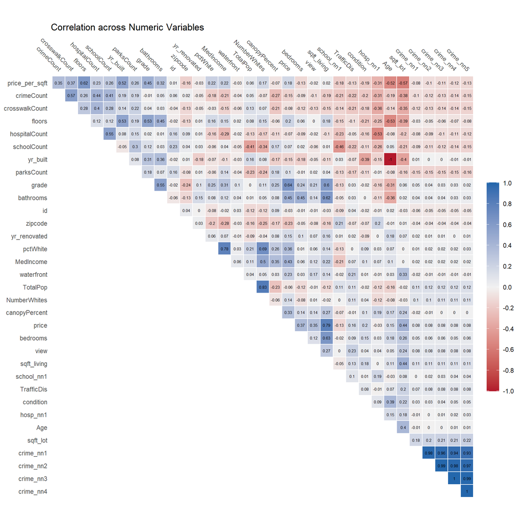

```r
# Select only numeric variables and remove rows with missing values
numericVars <- Seattle.sf_tracts2 %>%
  st_drop_geometry() %>%  # Remove geometry column if present
  select_if(is.numeric) %>%  # Select only numeric variables
  na.omit()  # Remove rows with missing values

# Calculate correlation matrix
correlation_matrix <- cor(numericVars)

numericVars %>%
  correlate() %>%
  autoplot() +
  geom_text(aes(label = round(r, digits=2)), size = 2) +
  labs(title = "Correlation across Numeric Variables")
```

Based on the correlation analysis chart, housing prices show a more positive association with the property’s grade, number of bathrooms, the percentage of the white population, median income, and canopy coverage. Additionally, we have identified potential multicollinearity among a few variables. For instance, the distances to the nearest 1-5 crime spots are highly positively correlated, as are the percentage of the white population and high income, and the house’s grade with the living area. To ensure the validity of our predictive model, we will address these multicollinearity concerns by carefully selecting variables to avoid including these highly correlated predictors simultaneously in the model-building phase.

## 3. Model Development

### 3.1 Baseline Model

have baseline model 0, take all variables into consideration, and show the model resultes

```r
##Baseline Model Reg0
Seattle_final_0 <- st_drop_geometry(Seattle.sf_tracts2)%>%
  select(-contains("Buffer"), -contains("distance"), -contains("date"), -yr_built, -canopy, -quintiles)%>%
  filter(price <= 2000000)

reg0 <- lm(price ~ ., data = Seattle_final_0)

summary(reg0)
```

[output not shown]

### 3.2 Finalized Model

Based on the baseline model outcomes, identify and remove variables that exhibit high multicollinearity, as well as those that lack statistical significance, to refine and establish Model 1.

```r
## Finalized Model Reg1
# Select Varibles
Seattle_final <- Seattle_final_0 %>%
  select(id, Age, price, bedrooms, bathrooms, sqft_living, waterfront, view, condition, grade,
         crimeCount, hosp_nn1, schoolCount, canopyPercent, parksCount, crosswalkCount, TrafficDis,
         pctWhite, MedIncome)%>%
  mutate_all(~replace(., is.na(.), 0))

reg1 <- lm(price ~ ., data = Seattle_final)

summary1 <- summary(reg1)

## Kable show summary of the model Reg1
coef_table <- as.data.frame(summary1$coefficients)
coef_table$significance <- ifelse(coef_table$`Pr(>|t|)` < 0.001, '***',
                                    ifelse(coef_table$`Pr(>|t|)` < 0.01, '**',
                                      ifelse(coef_table$`Pr(>|t|)` < 0.05, '*',
                                        ifelse(coef_table$`Pr(>|t|)` < 0.1, '.', ''))))
coef_table$p_value <- paste0(round(coef_table$`Pr(>|t|)`, digits = 3), coef_table$significance)
coef_table$'t value' <- round(coef_table$'t value', digits = 2)
coef_table$'Std. Error' <- round(coef_table$'Std. Error', digits = 2)
coef_table$Estimate <- round(coef_table$Estimate, digits = 2)

coef_table %>%
  select( -significance, -`Pr(>|t|)`) %>%
  kable(align = "r") %>%
  kable_styling(bootstrap_options = c("striped", "hover", "condensed")) %>%
  footnote(general_title = "\n", general = "Table x")
```

|  | Estimate | Std. Error | t value | p_value |
| --- | --- | --- | --- | --- |
| (Intercept) | -857440.49 | 21630.58 | -39.64 | 0*** |
| id | 0.00 | 0.00 | -1.66 | 0.097. |
| Age | 1418.88 | 65.02 | 21.82 | 0*** |
| bedrooms | -9657.29 | 2013.14 | -4.80 | 0*** |
| bathrooms | 8544.26 | 3385.82 | 2.52 | 0.012* |
| sqft_living | 156.72 | 4.06 | 38.59 | 0*** |
| waterfront | 369824.94 | 29830.30 | 12.40 | 0*** |
| view | 34670.11 | 2349.02 | 14.76 | 0*** |
| condition | 15696.81 | 2553.07 | 6.15 | 0*** |
| grade | 97543.58 | 2676.03 | 36.45 | 0*** |
| crimeCount | -14.79 | 4.79 | -3.09 | 0.002** |
| hosp_nn1 | -4.85 | 0.32 | -15.27 | 0*** |
| schoolCount | 852.05 | 693.45 | 1.23 | 0.219 |
| canopyPercent | 491.67 | 212.46 | 2.31 | 0.021* |
| parksCount | 12479.88 | 997.45 | 12.51 | 0*** |
| crosswalkCount | 893.27 | 226.28 | 3.95 | 0*** |
| TrafficDis | 39.76 | 5.28 | 7.54 | 0*** |
| pctWhite | 175054.98 | 14403.47 | 12.15 | 0*** |
| MedIncome | 2.97 | 0.22 | 13.24 | 0*** |

Table x

```r
## Results of the model
model_summary1 <- data.frame(
  Statistic = c("Multiple R-squared", "Adjusted R-squared", "F-statistic"),
  Value = c(
    summary1$r.squared,
    summary1$adj.r.squared,
    summary1$fstatistic[1]
  )
)
model_summary1 %>%
  kable() %>%
  kable_styling(bootstrap_options = c("striped", "hover", "condensed"))
```

| Statistic | Value |
| --- | --- |
| Multiple R-squared | 0.7626284 |
| Adjusted R-squared | 0.7619859 |
| F-statistic | 1186.9523303 |

An R-squared value of 0.76 suggests that approximately 76% of the variation in the housing price can be explained by the independent variables included in the model. This indicates a relatively strong relationship between the predictors and the response variable.

## 4. Model Diagnose:

Validating the predictive model requires a multifaceted approach to ensure its reliability and accuracy. This process should include a thorough examination of the variables to confirm their relevance and influence on the outcome. Residual analysis is crucial to identify any systematic deviations between predicted and actual values. Cross-validation techniques are essential for assessing the model’s performance across different data subsets, thereby ensuring its generalizability. Additionally, analyzing error distribution maps, like the one provided for the MAPE across neighborhoods, offers geographical insights into the model’s predictive behavior. Finally, quantifying the model’s precision through error metrics such as Root Mean Squared Error (RMSE) and Mean Absolute Error (MAE) provides a clear indication of the average magnitude of the model’s prediction errors. Together, these validation steps form a comprehensive framework to fine-tune the model for enhanced predictive performance.

### 4.1 Plot Coefficients:

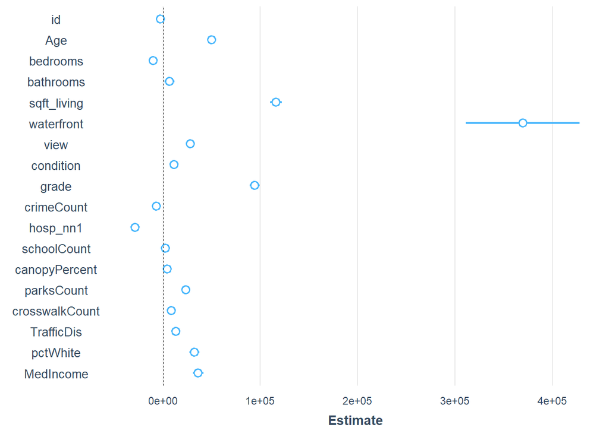

```r
## Plot coefficients
plot_summs(reg1, scale = TRUE)
```

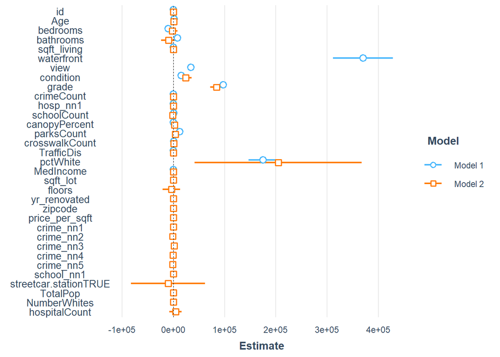

```r
## plot multiple model coeffs, use another model for comparison.
plot_summs(reg1, reg0)
```

### 4.2 Residual Examination

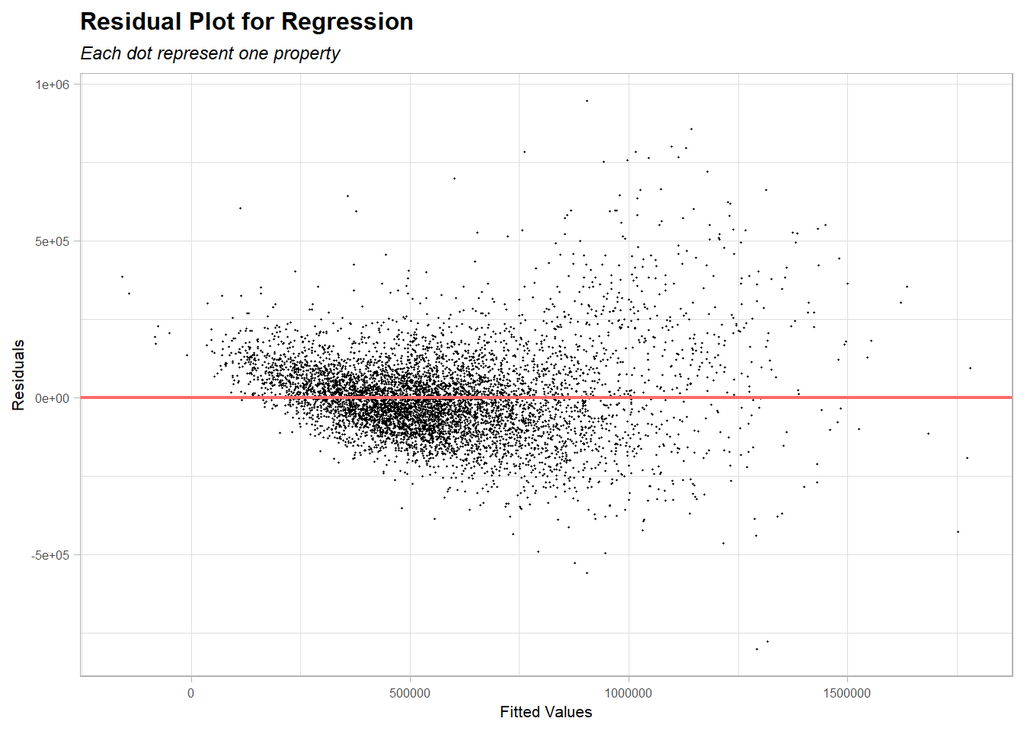

```r
residuals_df <- data.frame(Residuals = resid(reg1), Fitted = fitted(reg1))
ggplot(residuals_df, aes(x = Fitted, y = Residuals)) +
  geom_point(size = 0.25, color = "black") +
  geom_hline(yintercept = 0, color = "indianred1", size=0.8) +
  labs(title = "Residual Plot for Regression",
       subtitle = "Each dot represent one property ",
       x = "Fitted Values",
       y = "Residuals") +
  theme_light() +
  theme(plot.subtitle = element_text(size = 9,face = "italic"),
        plot.title = element_text(size = 12, face = "bold"),
        axis.text.x=element_text(size=6),
        axis.text.y=element_text(size=6),
        axis.title=element_text(size=8))
```

The residual plot offers a valuable visual representation of the model’s current performance, revealing the differences between the observed and predicted values. While the residuals predominantly cluster around the zero line—a promising sign—the pattern of increased spread with higher fitted values points to an opportunity for enhancing the model’s consistency. This phenomenon, known as heteroscedasticity, indicates that our model’s accuracy fluctuates with the value scale. To improve future predictions, we might consider exploring data transformations or more robust regression techniques that could stabilize the variance across the spectrum of predictions. Additionally, addressing the outliers that stand apart from the main cluster could refine the model’s accuracy.

### 4.3 Training and Testing Datasets

```r
# Split the dataset into a training set and a test set using stratified sampling
inTrain <- createDataPartition(
              y = paste(Seattle_final$sqft_lot, Seattle_final$view,
                        Seattle_final$yr_built, Seattle_final$school_nn1),
              p = .60, list = FALSE)  # Create a vector of indices for the training set

# Subset the dataset to create the training set
Seattle.training <- Seattle_final[inTrain,]  # Training set
# Subset the dataset to create the test set
Seattle.test <- Seattle_final[-inTrain,]     # Test set

# Fit a linear regression model to predict Sales Price using selected predictors
reg.training <-
  lm(price ~ ., data = as.data.frame(Seattle.training))

summary(reg.training)


# Make predictions on the test set and evaluate model performance

Seattle.test <-
  Seattle.test %>%  # Pipe the test set into the following operations
  # Add a column indicating the type of regression model used
  mutate(Regression = "Baseline Regression",
         # Predict sale prices using the trained regression model
         SalePrice.Predict = predict(reg.training, Seattle.test),
         # Calculate the difference between predicted and actual sale prices
         SalePrice.Error = SalePrice.Predict - price,
         # Calculate the absolute difference between predicted and actual sale prices
         SalePrice.AbsError = abs(SalePrice.Predict - price),
         # Calculate the absolute percentage error
         SalePrice.APE = (abs(SalePrice.Predict - price)) / price) %>%
  filter(price < 5000000)  # Filter out records with SalePrice greater than $5,000,000

# MAE and MAPE
MAE <- mean(Seattle.test$SalePrice.AbsError, na.rm = T)

MAPE <- mean(Seattle.test$SalePrice.APE, na.rm = T)

error_metrics <- data.frame(
  Metric = c("MAE", "MAPE"),
  Value = c(MAE, MAPE)
)
```

### 4.4 Cross Validation

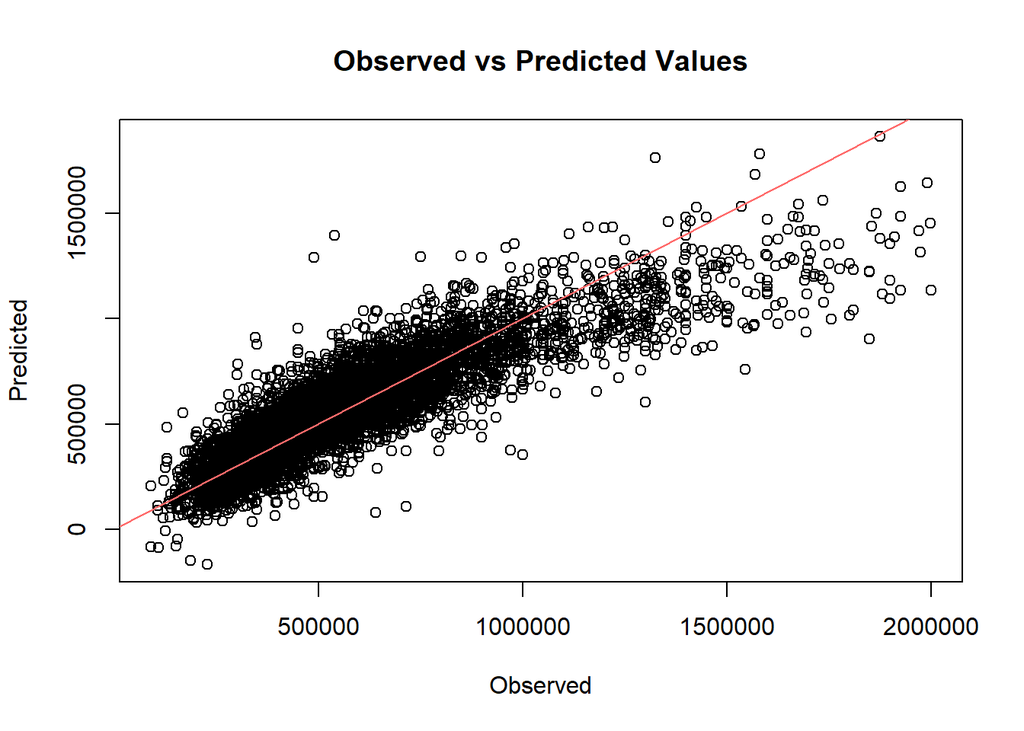

```r
# Load necessary libraries

# Define the control parameters for k-fold cross-validation
control <- trainControl(method = "cv",    # Use k-fold cross-validation
                        number = 10,      # Number of folds
                        verboseIter = TRUE,  # Show verbose output
                        returnData = FALSE,  # Don't return resampled data
                        savePredictions = TRUE,  # Save predictions
                        classProbs = FALSE,  # Don't compute class probabilities
                        summaryFunction = defaultSummary)  # Use default summary function

# Train the linear regression model using k-fold cross-validation
lm_cv <- train(price ~ .,  # Formula for the linear regression model
               data = Seattle_final,  # Dataset
               method = "lm",           # Specify "lm" for linear regression
               trControl = control)     # Use the defined control parameters

# View the cross-validation results
print(lm_cv)


# Plot observed versus predicted values
plot(lm_cv$pred$obs, lm_cv$pred$pred,
     xlab = "Observed", ylab = "Predicted",
     main = "Observed vs Predicted Values") +
     abline(0, 1, col = "indianred1", size=0.8)
```

The scatter plot of observed versus predicted values reveals that the regression model performs well at lower value ranges, as indicated by the clustering of points near the diagonal line where predictions match the observed values closely. However, as we move towards higher observed values, the points disperse more widely from the diagonal, suggesting the model’s predictive accuracy decreases in this higher range. Additionally, several points significantly stray from the diagonal, particularly at the upper end, suggesting potential outliers. Improving the model may involve investigating the causes of less accurate predictions at higher values, addressing outliers, adjusting model complexity, or exploring non-linear relationships.

### 4.5 Distribution of Sale Price Error Testing Set

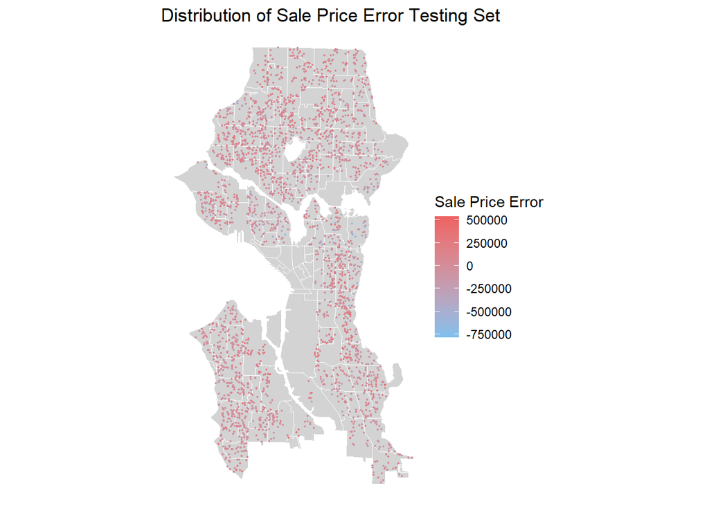

```r
Seattle.test_join <- left_join(Seattle.test, housingData, join_by(id == id))
Seattle.test_withgeo <-
  Seattle.test_join %>%
  st_as_sf(coords = c("long", "lat"), crs = 4326, agr = "constant") %>%
  st_transform(crs = 2926)

Seattle.test_withgeo$SalePrice.Error <- round(Seattle.test_withgeo$SalePrice.Error, digits = 2)

ggplot()+
  geom_sf(data = tracts, fill = "lightgrey", col = "white") +
  geom_sf(data=Seattle.test_withgeo, aes(colour = Seattle.test_withgeo$SalePrice.Error), size=0.3)+
  scale_color_continuous(low = "skyblue2", high = "indianred2", name= "Sale Price Error ") +
  labs(title = "Distribution of Sale Price Error Testing Set") +
  theme_void()
```

### 4.6 Mean Absolute Percentage Error By Neighborhood

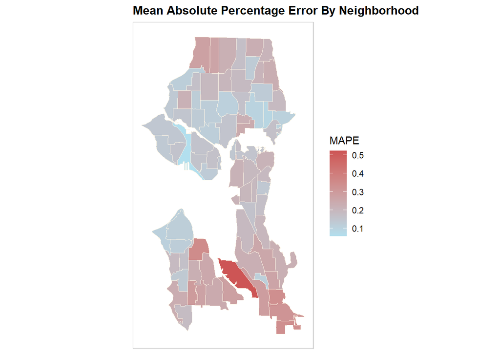

```r
to_plot <- st_intersection(Seattle.test_withgeo, neighborhood %>% dplyr::select("S_HOOD")) %>%
  st_drop_geometry() %>%
  group_by(S_HOOD) %>%
  summarise(mean.MAPE = mean(SalePrice.APE, na.rm = T)) %>%
  left_join(neighborhood) %>%
  st_sf()
to_plot %>%
  ggplot() +
      geom_sf(aes(fill = mean.MAPE), color="oldlace") +
  scale_fill_continuous(low = "lightblue2", high = "indianred3", name= "MAPE") +
  theme(
        axis.text.x=element_blank(),
        axis.ticks.x=element_blank(),
        axis.text.y=element_blank(),
        axis.ticks.y=element_blank(),
        plot.title = element_text(size = 12, face = "bold"),
        panel.background = element_blank(),
        panel.border = element_rect(colour = "grey", fill=NA, size=0.4)
        ) +
  labs(title = "Mean Absolute Percentage Error By Neighborhood")
```

This map presents the Mean Absolute Percentage Error (MAPE) for a housing value prediction model, offering insight into its performance across various neighborhoods. The map reveals a non-uniform predictive accuracy; notably, neighborhoods like Rainier Beach, South Park, and Highland Park exhibit higher errors, indicating the model’s predictions are notably less precise here.

Moreover, this discrepancy may highlight the need for more nuanced, area-specific data that captures the microeconomic conditions of these neighborhoods. By integrating more granular data and refining the model to account for localized influences, the predictive accuracy could be markedly improved.

### 4.7 RMSE, MAE

```r
# Set up leave-one-out cross-validation
control <- trainControl(method = "LOOCV",     # Use leave-one-out cross-validation
                        number = nrow(Seattle_final),  # Number of folds = number of observations
                        verboseIter = TRUE,  # Show verbose output
                        returnData = FALSE,  # Don't return resampled data
                        savePredictions = TRUE,  # Save predictions
                        classProbs = FALSE,  # Don't compute class probabilities
                        summaryFunction = defaultSummary)  # Use default summary function

# Train the linear regression model using leave-one-out cross-validation
lm_loocv <- train(price ~ .,  # Formula for the linear regression model
                  data = Seattle_final,  # Dataset
                  method = "lm",           # Specify "lm" for linear regression
                  trControl = control)     # Use the defined control parameters


# 6669 fold in total
```

```r
# View the cross-validation results
loocv_results <- lm_loocv['results']
statistic_summary <- do.call(rbind, loocv_results) %>% select(-contains("intercept"))


kbl(statistic_summary) %>%
  kable_styling(bootstrap_options = "striped", full_width = T, position = "left")
```

|  | RMSE | Rsquared | MAE |
| --- | --- | --- | --- |
| results | 134735.7 | 0.7605054 | 95819.2 |

The Root Mean Square Error (RMSE) of approximately 134,736 for the Seattle housing value prediction model indicates the standard deviation of the prediction errors, which means that typically, the model’s predictions deviate from the actual values by this amount. In the context of Seattle’s real estate market, where housing values can vary greatly, this RMSE might suggest that while the model is useful, its predictions are not consistently close to actual sale prices. The R-squared value indicates that 76% of the variability in housing prices is explained by the model, which is a positive sign of fit, but it doesn’t necessarily guarantee accuracy on individual predictions. Additionally, the Mean Absolute Error (MAE) of around 95,819 suggests that the model’s average prediction error is within this range, providing further insight into the model’s performance. The relatively high RMSE compared to the MAE suggests there might be some large deviations for certain predictions, potentially pointing towards outliers or instances where the model fails to capture the underlying value drivers. It would be beneficial to delve into the specific areas where the model overshoots or undershoots to fine-tune its predictive capabilities.